# ShapleyForest on Real Data: Ames Housing Prices

Author

Timothy Shen

Published

June 9, 2026

# 1 Introduction

The other vignettes in this package run Shapley Forest (SF) on gene-expression panels — useful benchmarks, but hard to sanity-check unless you know the biology. This vignette runs the **same algorithm, unchanged**, on a dataset anyone can reason about: the **Ames Housing** data (De Cock, 2011), 2930 homes sold in Ames, Iowa, described by 33 numeric attributes (square footage, room counts, garage size, year built, lot size, …).

The appeal for this demo is that the *statistical* problem is identical to the genomics case — many correlated, partially-redundant measurements competing to explain an outcome — but the *features themselves* are intuitive. You already know that bigger houses have more rooms, that finished basements correlate with total square footage, and that garage size tracks lot size. SF’s job is to take that tangle of correlated measurements and tell you which ones are *robustly, stably* informative about price — exactly as it would for a tangle of co-expressed genes.

The vignette proceeds in four stages:

1. Data loading and a look at how the features correlate
2. WGCNA — soft-threshold selection, module detection, and kME refinement
3. Single SF run and output exploration
4. Held-out evaluation: how much predictive power lives in the stable set?

# 2 Data

The dataset ships with the package — no extra downloads needed.

```r
library(shapleyforest)

data(housing)

X <- as.data.frame(housing$X)
y <- housing$y

cat("Homes    :", nrow(X), "\n")
```

```
Homes    : 2930
```

```r
cat("Features :", ncol(X), "\n")
```

```
Features : 33
```

```r
cat("Price ($):", paste(format(round(range(y)), big.mark = ","), collapse = " - "), "\n")
```

```
Price ($):  12,789 - 755,000
```

```r
knitr::kable(
  data.frame(Feature = colnames(X),
             Mean    = round(colMeans(X), 1),
             SD      = round(apply(X, 2, sd), 1)),
  caption = "Numeric property attributes bundled in `housing$X`."
)
```

Numeric property attributes bundled in `housing$X`.

|  | Feature | Mean | SD |
| --- | --- | --- | --- |
| Lot_Frontage | Lot_Frontage | 57.6 | 33.5 |
| Lot_Area | Lot_Area | 10147.9 | 7880.0 |
| Year_Built | Year_Built | 1971.4 | 30.2 |
| Year_Remod_Add | Year_Remod_Add | 1984.3 | 20.9 |
| Mas_Vnr_Area | Mas_Vnr_Area | 101.1 | 178.6 |
| BsmtFin_SF_1 | BsmtFin_SF_1 | 4.2 | 2.2 |
| BsmtFin_SF_2 | BsmtFin_SF_2 | 49.7 | 169.1 |
| Bsmt_Unf_SF | Bsmt_Unf_SF | 559.1 | 439.5 |
| Total_Bsmt_SF | Total_Bsmt_SF | 1051.3 | 441.0 |
| First_Flr_SF | First_Flr_SF | 1159.6 | 391.9 |
| Second_Flr_SF | Second_Flr_SF | 335.5 | 428.4 |
| Gr_Liv_Area | Gr_Liv_Area | 1499.7 | 505.5 |
| Bsmt_Full_Bath | Bsmt_Full_Bath | 0.4 | 0.5 |
| Bsmt_Half_Bath | Bsmt_Half_Bath | 0.1 | 0.2 |
| Full_Bath | Full_Bath | 1.6 | 0.6 |
| Half_Bath | Half_Bath | 0.4 | 0.5 |
| Bedroom_AbvGr | Bedroom_AbvGr | 2.9 | 0.8 |
| Kitchen_AbvGr | Kitchen_AbvGr | 1.0 | 0.2 |
| TotRms_AbvGrd | TotRms_AbvGrd | 6.4 | 1.6 |
| Fireplaces | Fireplaces | 0.6 | 0.6 |
| Garage_Cars | Garage_Cars | 1.8 | 0.8 |
| Garage_Area | Garage_Area | 472.7 | 215.2 |
| Wood_Deck_SF | Wood_Deck_SF | 93.8 | 126.4 |
| Open_Porch_SF | Open_Porch_SF | 47.5 | 67.5 |
| Enclosed_Porch | Enclosed_Porch | 23.0 | 64.1 |
| Three_season_porch | Three_season_porch | 2.6 | 25.1 |
| Screen_Porch | Screen_Porch | 16.0 | 56.1 |
| Pool_Area | Pool_Area | 2.2 | 35.6 |
| Misc_Val | Misc_Val | 50.6 | 566.3 |
| Mo_Sold | Mo_Sold | 6.2 | 2.7 |
| Year_Sold | Year_Sold | 2007.8 | 1.3 |
| Longitude | Longitude | -93.6 | 0.0 |
| Latitude | Latitude | 42.0 | 0.0 |

## 2.1 Feature correlation structure

Before fitting anything, it’s worth seeing *why* this is a hard selection problem: most of these measurements move together. Square footage, basement size, room counts, and garage capacity all rise and fall with the overall size of the home — so a model can “explain” price with almost any one of them as a stand-in for the others. SF’s screening + shadow-stability machinery exists precisely to cut through blocks like this.

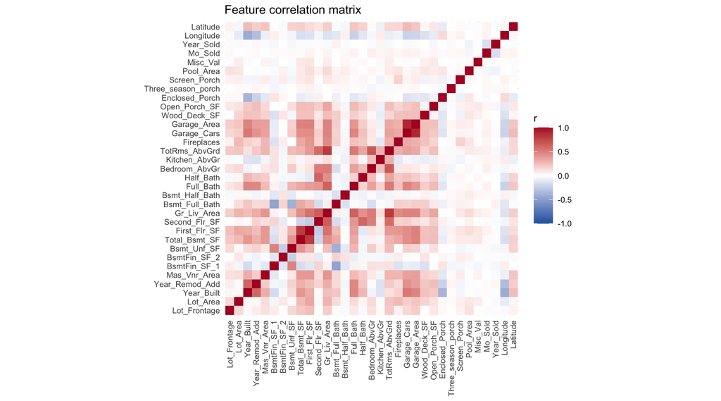

Pairwise Pearson correlation among the 33 housing features. Blocks of mutually-correlated features (e.g. living area, basement size, room counts) are exactly the kind of redundancy SF is designed to navigate.

```r
library(ggplot2)

cor_mat <- cor(X)
cor_df  <- as.data.frame(as.table(cor_mat))
names(cor_df) <- c("Feature_1", "Feature_2", "r")

ggplot(cor_df, aes(Feature_1, Feature_2, fill = r)) +
  geom_tile() +
  scale_fill_gradient2(low = "#2166AC", mid = "white", high = "#B2182B",
                       midpoint = 0, limits = c(-1, 1)) +
  coord_equal() +
  labs(title = "Feature correlation matrix", x = NULL, y = NULL) +
  theme_minimal(base_size = 9) +
  theme(axis.text.x = element_text(angle = 90, hjust = 1, vjust = 0.5))
```

# 3 WGCNA Module Detection

We perform WGCNA manually so we can inspect the network structure before handing modules to SF.

```r
library(WGCNA)
options(stringsAsFactors = FALSE)
enableWGCNAThreads()
```

```
Allowing parallel execution with up to 7 working processes.
```

## 3.1 Soft-threshold power selection

WGCNA constructs a weighted co-feature network by raising pairwise correlations to a soft-thresholding power $\beta$. The chosen power should make the network approximately **scale-free** ($R^2 \geq 0.8$) while keeping **mean connectivity** reasonably high.

```r
powers <- c(1:10, seq(12, 20, by = 2))

sft <- pickSoftThreshold(
  X,
  powerVector = powers,
  networkType = "signed hybrid",
  verbose     = 0
)
```

```
   Power SFT.R.sq slope truncated.R.sq mean.k. median.k. max.k.
1      1   0.0734 -1.85        -0.1890 3.35000  3.33e+00 8.4800
2      2   0.1440 -2.74        -0.0824 1.07000  6.27e-01 3.8800
3      3   0.1600 -2.11         0.0201 0.47400  1.37e-01 2.0900
4      4   0.1560 -1.81         0.0030 0.25600  4.14e-02 1.2400
5      5   0.8120 -0.67         0.9250 0.15800  1.10e-02 0.7870
6      6   0.1670 -2.45        -0.0661 0.10700  3.04e-03 0.5720
7      7   0.0952 -1.72        -0.1580 0.07760  8.81e-04 0.4780
8      8   0.1070 -2.38        -0.0966 0.05900  2.64e-04 0.4110
9      9   0.1890 -3.07        -0.0419 0.04650  8.18e-05 0.3580
10    10   0.1380 -2.68        -0.0130 0.03750  2.59e-05 0.3160
11    12   0.2150 -2.89         0.0162 0.02570  2.74e-06 0.2480
12    14   0.2750 -2.76         0.1890 0.01830  3.02e-07 0.1960
13    16   0.3210 -2.79         0.1260 0.01340  3.42e-08 0.1550
14    18   0.3430 -2.50         0.2180 0.00994  3.92e-09 0.1220
15    20   0.3580 -2.34         0.2270 0.00748  4.52e-10 0.0969
```

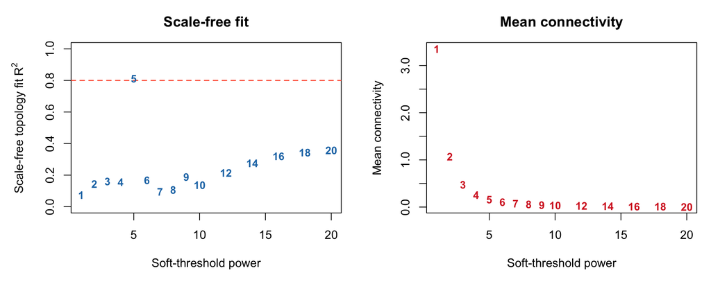

```r
par(mfrow = c(1, 2), mar = c(5, 5, 3, 1))

plot(sft$fitIndices[, 1],
     -sign(sft$fitIndices[, 3]) * sft$fitIndices[, 2],
     xlab = "Soft-threshold power",
     ylab = expression(paste("Scale-free topology fit R"^2)),
     main = "Scale-free fit",
     type = "n", ylim = c(0, 1))
abline(h = 0.8, lty = 2, col = "tomato", lwd = 1.5)
text(sft$fitIndices[, 1],
     -sign(sft$fitIndices[, 3]) * sft$fitIndices[, 2],
     labels = powers, col = "#1F77B4", cex = 0.9, font = 2)

plot(sft$fitIndices[, 1],
     sft$fitIndices[, 5],
     xlab = "Soft-threshold power",
     ylab = "Mean connectivity",
     main = "Mean connectivity",
     type = "n")
text(sft$fitIndices[, 1],
     sft$fitIndices[, 5],
     labels = powers, col = "#D62728", cex = 0.9, font = 2)
```

## 3.2 Module detection

```r
SOFT_POWER <- 5L

net <- blockwiseModules(
  X,
  power             = SOFT_POWER,
  networkType       = "signed hybrid",
  TOMType           = "signed",
  minModuleSize     = 5L,
  mergeCutHeight    = 0.25,
  numericLabels     = FALSE,
  pamRespectsDendro = FALSE,
  saveTOMs          = FALSE,
  verbose           = 0
)

table(net$colors)   # grey = unassigned (independent pool in SF)
```

```
     blue      grey turquoise
        7        19         7
```

With 33 features, expect a handful of modules — typically one grouping size-related measurements (living area, basement, first/second floor), another for bath and room counts, another for garage and outdoor features, and a grey (independent) pool for attributes that don’t co-vary strongly with anything else (e.g. `Mo_Sold`, `Misc_Val`, `Year_Sold`).

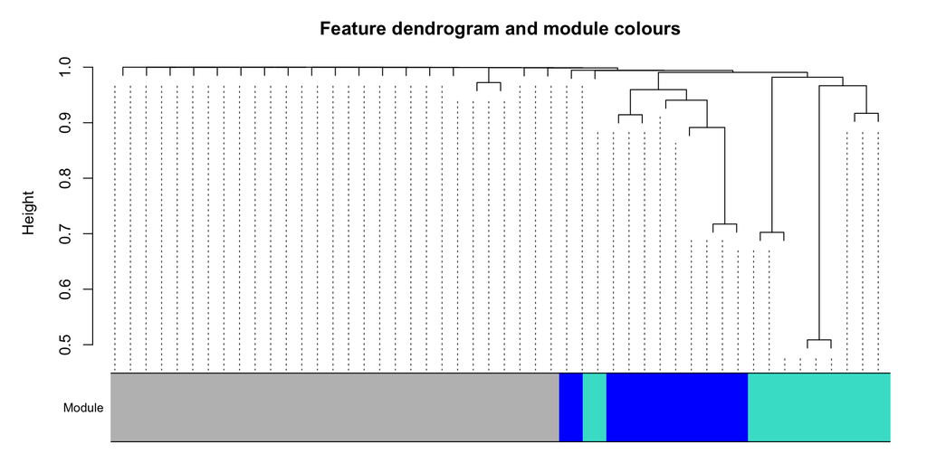

Feature dendrogram with module colour bar. Grey = unassigned features treated as the independent pool in SF.

```r
plotDendroAndColors(
  net$dendrograms[[1]],
  net$colors[net$blockGenes[[1]]],
  "Module",
  dendroLabels = FALSE,
  hang         = 0.03,
  addGuide     = TRUE,
  guideHang    = 0.05,
  main         = "Feature dendrogram and module colours"
)
```

## 3.3 Eigengene-based connectivity (kME)

Module eigengenes summarise each module’s profile as a single representative vector. Correlating every feature with each module eigengene gives its **module membership** ($k_{ME}$) — a continuous measure of how central a feature is to that module.

```r
MEs <- net$MEs
kME <- as.data.frame(signedKME(X, MEs, outputColumnName = "kME"))

# kME of each feature to its originally assigned module
feat_kME <- vapply(seq_along(net$colors), function(i) {
  col <- paste0("kME", net$colors[i])
  if (col %in% colnames(kME)) kME[i, col] else NA_real_
}, numeric(1))
```

## 3.4 Hub features

Intramodular **hub features** are the attributes most strongly correlated with their module eigengene — the ones that best represent what the module captures. For the size-related module you’d expect to see `Gr_Liv_Area`, `Total_Bsmt_SF`, `First_Flr_SF`; for the garage module, `Garage_Area` and `Garage_Cars`.

```r
hub_df <- data.frame(
  feature = colnames(X),
  module  = net$colors,
  kME     = feat_kME,
  stringsAsFactors = FALSE
)
hub_df <- hub_df[hub_df$module != "grey" & !is.na(hub_df$kME), ]

top_hubs <- hub_df[order(-hub_df$kME), ][seq_len(min(20L, nrow(hub_df))), ]
top_hubs
```

```
                      feature    module       kME
Gr_Liv_Area       Gr_Liv_Area      blue 0.9132212
TotRms_AbvGrd   TotRms_AbvGrd      blue 0.8760499
Garage_Area       Garage_Area turquoise 0.8342837
Garage_Cars       Garage_Cars turquoise 0.8310239
Second_Flr_SF   Second_Flr_SF      blue 0.8013566
Total_Bsmt_SF   Total_Bsmt_SF turquoise 0.7605152
First_Flr_SF     First_Flr_SF turquoise 0.7324557
Year_Built         Year_Built turquoise 0.7151729
Bedroom_AbvGr   Bedroom_AbvGr      blue 0.6988173
Full_Bath           Full_Bath      blue 0.6696767
Year_Remod_Add Year_Remod_Add turquoise 0.6000724
Half_Bath           Half_Bath      blue 0.5774798
Mas_Vnr_Area     Mas_Vnr_Area turquoise 0.5666682
Fireplaces         Fireplaces      blue 0.4226249
```

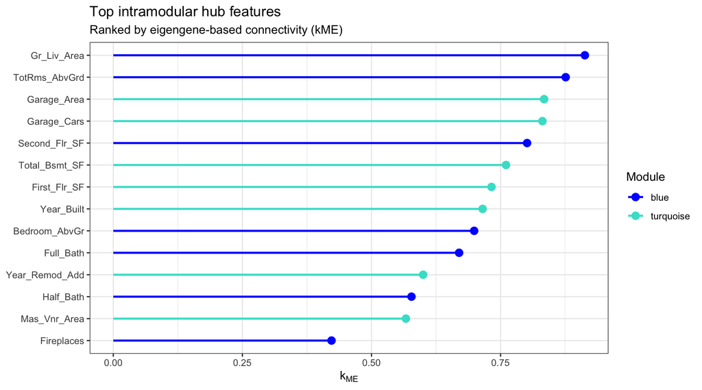

Top hub features ranked by eigengene-based connectivity (kME), coloured by WGCNA module.

```r
library(ggplot2)

ggplot(top_hubs, aes(x = reorder(feature, kME), y = kME, colour = module)) +
  geom_segment(aes(xend = feature, y = 0, yend = kME), linewidth = 0.9) +
  geom_point(size = 3) +
  scale_colour_identity(guide = "legend", name = "Module",
                        breaks = unique(top_hubs$module),
                        labels = unique(top_hubs$module)) +
  coord_flip() +
  labs(title    = "Top intramodular hub features",
       subtitle = "Ranked by eigengene-based connectivity (kME)",
       x = NULL, y = expression(k[ME])) +
  theme_bw()
```

## 3.5 Final module membership (kME-refined)

As a final refinement we reassign each feature to the module whose eigengene it correlates with most strongly, then pass this membership to SF.

```r
module_names <- sub("^kME", "", colnames(kME))
best_module  <- module_names[max.col(as.matrix(kME), ties.method = "first")]
module_membership <- best_module
names(module_membership) <- colnames(X)
module_membership[module_membership == "grey"] <- "independent"

table(clustering = net$colors, kME_refined = module_membership)
```

```
           kME_refined
clustering  blue independent turquoise
  blue         7           0         0
  grey         5           9         5
  turquoise    0           0         7
```

# 4 Single SF Run

```r
sf_setup()
```

```r
set.seed(42)
fit <- sf(
  X                 = X,
  y                 = y,
  module_membership = module_membership,
  screen_params     = screen_control(min_ntree = 100L),
  select_params     = select_control(min_ntree = 100L, n_boots = 20L),
  final_ntree       = 200L,
  backend           = "python",
  verbose           = 1L
)
```

```
Screening ...
Selecting stable features ...
Stable features: 15
Fitting final model ...
Done.
```

## 4.1 Stable set

```r
stable <- fit$feature_list$feature_name
cat("Stable features selected:", length(stable), "of", ncol(X), "\n")
```

```
Stable features selected: 15 of 33
```

```r
head(sort(fit$stability_freq, decreasing = TRUE), 15)
```

```
    Year_Built    Gr_Liv_Area  Total_Bsmt_SF    Garage_Cars Year_Remod_Add
           1.0            1.0            1.0            1.0            1.0
  First_Flr_SF    Garage_Area     Fireplaces      Full_Bath  Second_Flr_SF
           1.0            1.0            1.0            1.0            1.0
Bsmt_Full_Bath   BsmtFin_SF_1      Longitude   Wood_Deck_SF   Screen_Porch
           1.0            1.0            1.0            1.0            0.7
```

## 4.2 Final SHAP

```r
fit$final_SHAP
```

```
                 feature_name variable_importance module_membership
Year_Built         Year_Built          13841.0814         turquoise
Gr_Liv_Area       Gr_Liv_Area          12783.1990              blue
Total_Bsmt_SF   Total_Bsmt_SF          10267.3449         turquoise
Garage_Cars       Garage_Cars           9205.6237         turquoise
Year_Remod_Add Year_Remod_Add           7351.9396         turquoise
First_Flr_SF     First_Flr_SF           7100.6949         turquoise
Garage_Area       Garage_Area           6090.7263         turquoise
Fireplaces         Fireplaces           6071.0169              blue
Full_Bath           Full_Bath           4599.7052              blue
Second_Flr_SF   Second_Flr_SF           4464.4243              blue
Bsmt_Full_Bath Bsmt_Full_Bath           2454.6216       independent
BsmtFin_SF_1     BsmtFin_SF_1           2394.9074              blue
Longitude           Longitude           2274.0713              blue
Wood_Deck_SF     Wood_Deck_SF           1319.4951       independent
Screen_Porch     Screen_Porch            357.9318       independent
               mean_abs_shap se_abs_shap ci_lower_abs ci_upper_abs
Year_Built          5832.173    125.0100     5587.153     6077.192
Gr_Liv_Area         5762.470    116.9355     5533.276     5991.663
Total_Bsmt_SF       7233.443    168.5139     6903.156     7563.730
Garage_Cars         5383.440     92.6464     5201.853     5565.027
Year_Remod_Add      5913.513    115.3894     5687.350     6139.676
First_Flr_SF        6608.036    148.3660     6317.238     6898.833
Garage_Area         5347.243     95.6691     5159.731     5534.754
Fireplaces          5778.893    113.4484     5556.534     6001.252
Full_Bath           6787.826    154.4007     6485.200     7090.451
Second_Flr_SF       6153.199    137.9611     5882.795     6423.603
Bsmt_Full_Bath      5569.068    105.9707     5361.365     5776.770
BsmtFin_SF_1        6546.172    141.1238     6269.570     6822.775
Longitude           6525.553    146.9807     6237.471     6813.635
Wood_Deck_SF        5310.349     95.5268     5123.117     5497.582
Screen_Porch        5825.408    109.6538     5610.486     6040.329
               mean_signed_shap se_signed_shap ci_lower_signed ci_upper_signed
Year_Built              35.8669       165.0454       -287.6220        359.3558
Gr_Liv_Area           -353.9081       158.0131       -663.6138        -44.2024
Total_Bsmt_SF         3055.0027       207.5432       2648.2181       3461.7873
Garage_Cars          -2959.7725       124.4474      -3203.6893      -2715.8557
Year_Remod_Add          67.6780       158.9096       -243.7847        379.1407
First_Flr_SF          2443.7632       186.7666       2077.7008       2809.8257
Garage_Area          -2460.2104       129.8005      -2714.6194      -2205.8015
```

[output cut: 9 more lines]

```
Year_Built                1.0
Gr_Liv_Area               1.0
Total_Bsmt_SF             1.0
Garage_Cars               1.0
Year_Remod_Add            1.0
First_Flr_SF              1.0
Garage_Area               1.0
Fireplaces                1.0
Full_Bath                 1.0
Second_Flr_SF             1.0
Bsmt_Full_Bath            1.0
BsmtFin_SF_1              1.0
Longitude                 1.0
Wood_Deck_SF              1.0
Screen_Porch              0.7
```

## 4.3 Stability plot

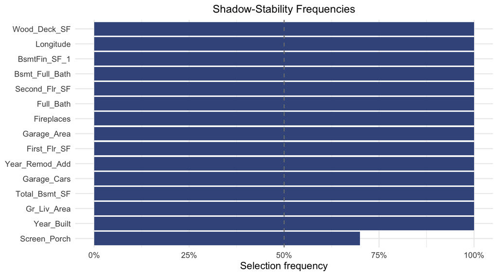

```r
plot_stability(fit)
```

## 4.4 Decision plot

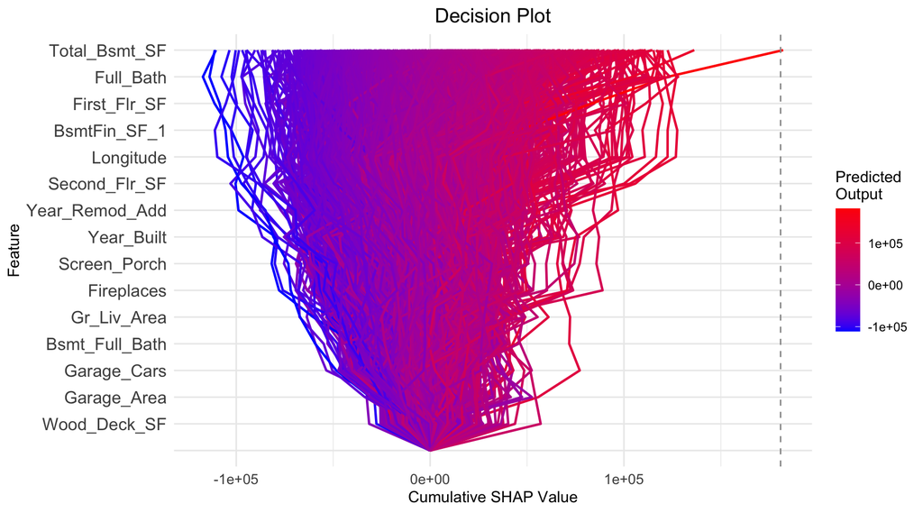

```r
plot_decisions(fit)
```

## 4.5 Elbow Plot

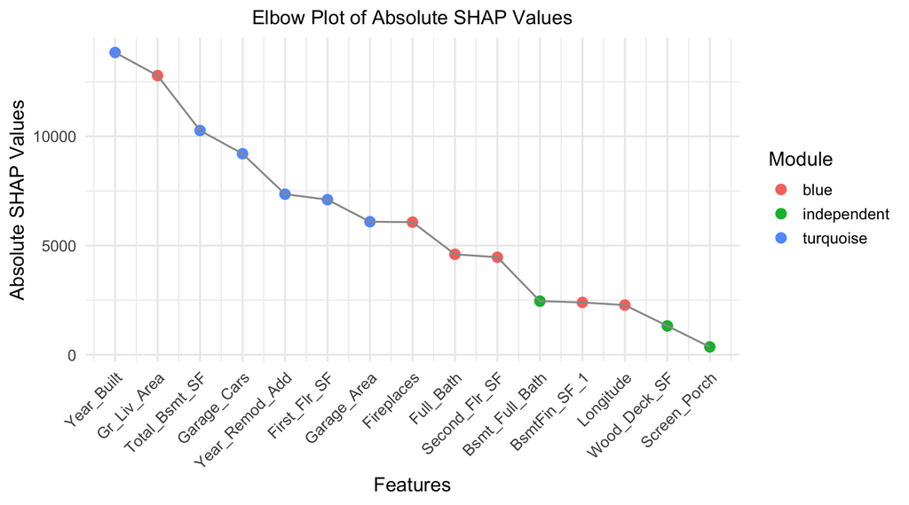

Scree plot of mean |SHAP| for each stable feature, ranked by importance and coloured by module. The elbow marks the natural drop-off point where additional features contribute diminishing predictive value.

```r
plot_elbow(fit)
```

## 4.6 Feature importance

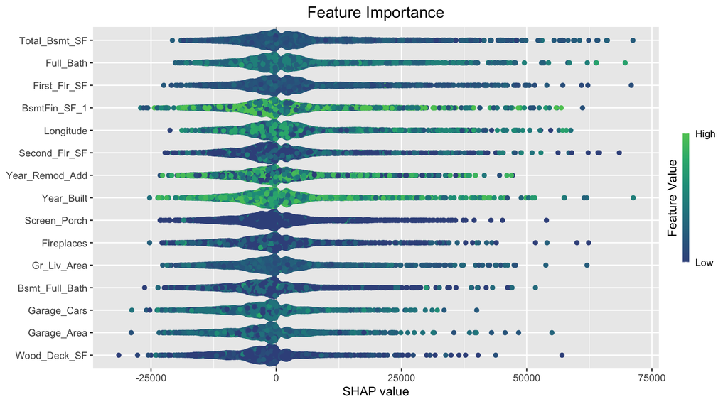

```r
plot_importance(fit, top_n = 15)
```

# 5 Held-Out Evaluation

*Do we lose anything by discarding the other features?* We hold out 20% of homes, fit a random forest on the stable set alone, and compare it against a forest trained on the full 33-feature table.

```r
set.seed(1)
n         <- nrow(X)
test_idx  <- sample(seq_len(n), size = round(0.2 * n))
train_idx <- setdiff(seq_len(n), test_idx)

stable <- fit$feature_list$feature_name

rf_stable <- ranger::ranger(
  y ~ ., num.trees = 300L, seed = 1L,
  data = data.frame(y = y[train_idx], X[train_idx, stable, drop = FALSE])
)
rf_full <- ranger::ranger(
  y ~ ., num.trees = 300L, seed = 1L,
  data = data.frame(y = y[train_idx], X[train_idx, , drop = FALSE])
)

pred_stable <- predict(rf_stable, data.frame(X[test_idx, stable, drop = FALSE]))$predictions
pred_full   <- predict(rf_full,   data.frame(X[test_idx, , drop = FALSE]))$predictions

rmse <- function(actual, pred) sqrt(mean((actual - pred)^2))
r2   <- function(actual, pred) 1 - sum((actual - pred)^2) / sum((actual - mean(actual))^2)

results <- data.frame(
  Model      = c("Stable features only", "All 33 features"),
  N_features = c(length(stable), ncol(X)),
  RMSE       = c(rmse(y[test_idx], pred_stable), rmse(y[test_idx], pred_full)),
  R_squared  = c(r2(y[test_idx], pred_stable),   r2(y[test_idx], pred_full))
)
knitr::kable(results, digits = c(0, 0, 0, 3),
             caption = "Held-out (20%) prediction accuracy: stable subset vs. full feature table.")
```

Held-out (20%) prediction accuracy: stable subset vs. full feature table.

| Model | N_features | RMSE | R_squared |
| --- | --- | --- | --- |
| Stable features only | 15 | 28694 | 0.883 |
| All 33 features | 33 | 28261 | 0.887 |

Stable-set model lands close to the full-feature model on both RMSE and R². Thus the SF found a small, *stable* subset of measurements that carries nearly all of the predictive signal in the other 20-odd correlated, redundant attributes.

This can further be shown below with the actual vs predicted sale price between the two.

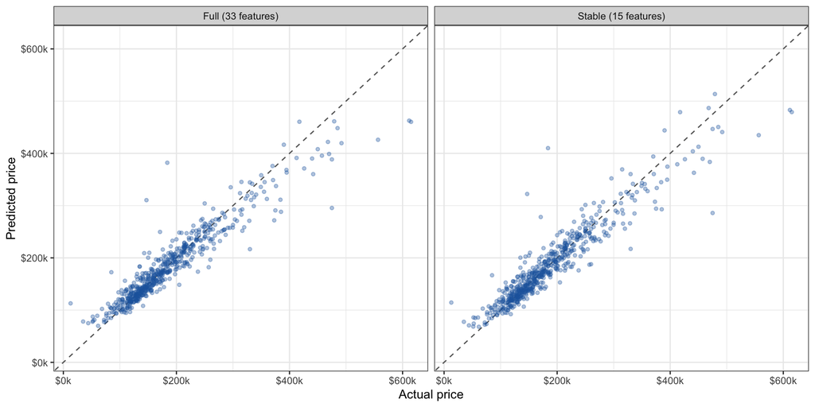

```r
library(ggplot2)

plot_df <- rbind(
  data.frame(actual = y[test_idx], predicted = pred_stable,
             model = paste0("Stable (", length(stable), " features)")),
  data.frame(actual = y[test_idx], predicted = pred_full,
             model = "Full (33 features)")
)

lims <- range(c(plot_df$actual, plot_df$predicted))

ggplot(plot_df, aes(x = actual, y = predicted)) +
  geom_abline(slope = 1, intercept = 0, linetype = "dashed", colour = "grey40") +
  geom_point(alpha = 0.35, size = 1.2, colour = "#2166AC") +
  facet_wrap(~ model) +
  scale_x_continuous(labels = scales::dollar_format(scale = 1e-3, suffix = "k"),
                     limits = lims) +
  scale_y_continuous(labels = scales::dollar_format(scale = 1e-3, suffix = "k"),
                     limits = lims) +
  labs(x = "Actual price", y = "Predicted price") +
  theme_bw()
```

## 5.1 Shapley Forest Variants

We know can explore the different variants of SF.

```r
VARIANTS <- list(
  split       = select_control(shadow_mode = "split",
                               use_dml_residual = FALSE,
                               min_ntree = 100L, n_boots = 20L),
  split_dml   = select_control(shadow_mode = "split",
                               use_dml_residual = TRUE, dml_scope = "indep",
                               min_ntree = 100L, n_boots = 20L),
  split_mdml  = select_control(shadow_mode = "split",
                               use_dml_residual = TRUE, dml_scope = "all_modules",
                               min_ntree = 100L, n_boots = 20L),
  within_dml  = select_control(shadow_mode = "within_module",
                               use_dml_residual = TRUE, dml_scope = "indep",
                               min_ntree = 100L, n_boots = 20L),
  within_mdml = select_control(shadow_mode = "within_module",
                               use_dml_residual = TRUE, dml_scope = "all_modules",
                               min_ntree = 100L, n_boots = 20L)
)

fits <- lapply(VARIANTS, function(sl) {
  set.seed(42)
  sf(
    X                 = X,
    y                 = y,
    module_membership = module_membership,
    screen_params     = screen_control(min_ntree = 100L),
    select_params     = sl,
    final_ntree       = 200L,
    backend           = "python",
    verbose           = 0L
  )
})
```

We first look at the default SF run with just `split` as the criterion.

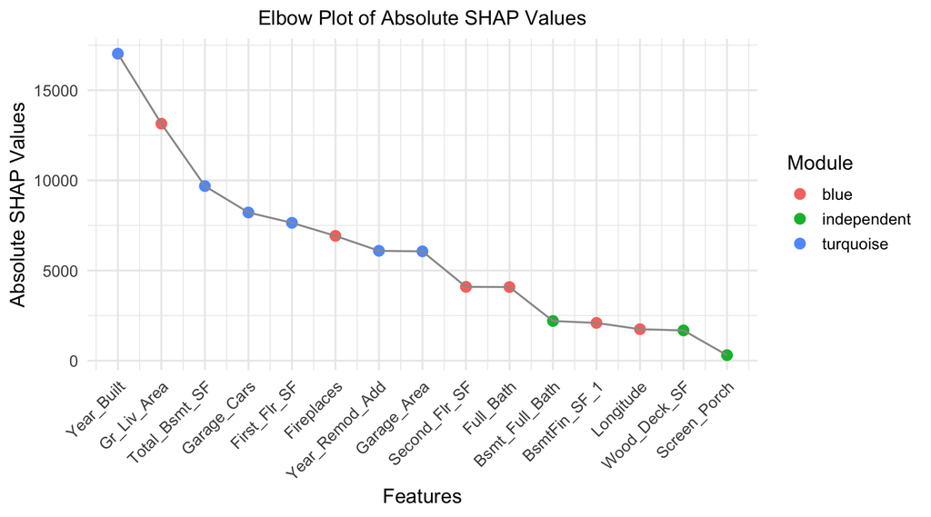

```r
plot_elbow(fits$split)
```

With the `Debiased Machine Learning` included for the independent, only the ordering changes but the stable set remains the same.

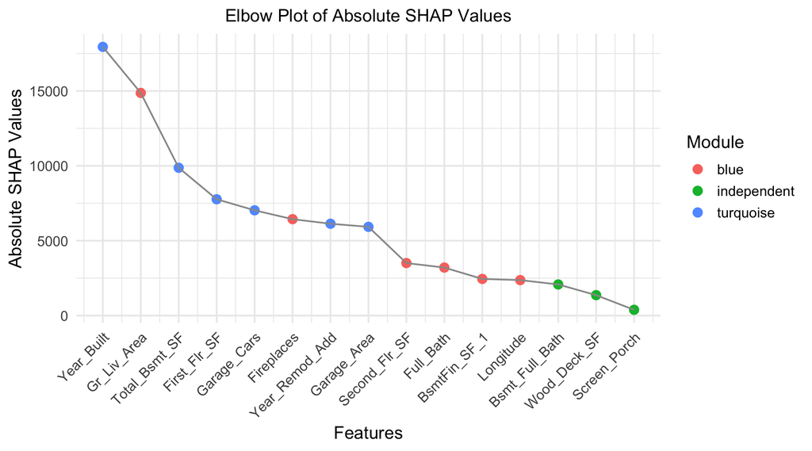

```r
plot_elbow(fits$split_dml)
```

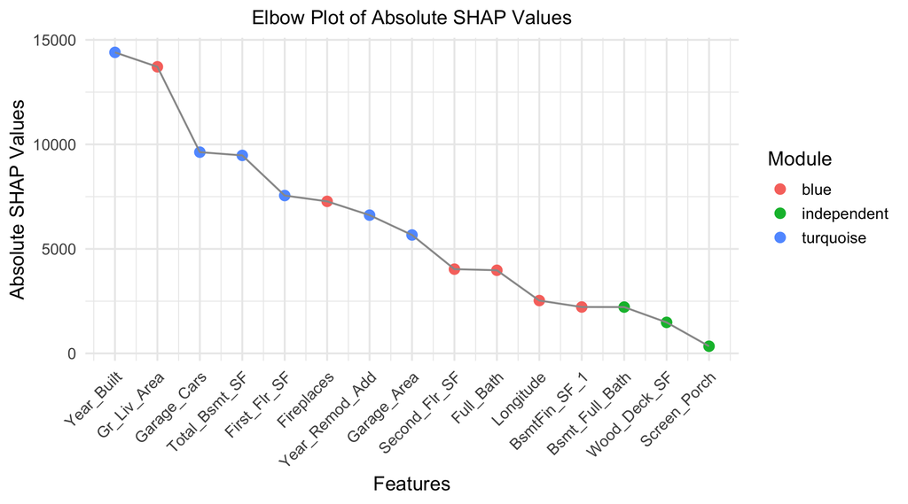

```r
plot_elbow(fits$within_dml)
```

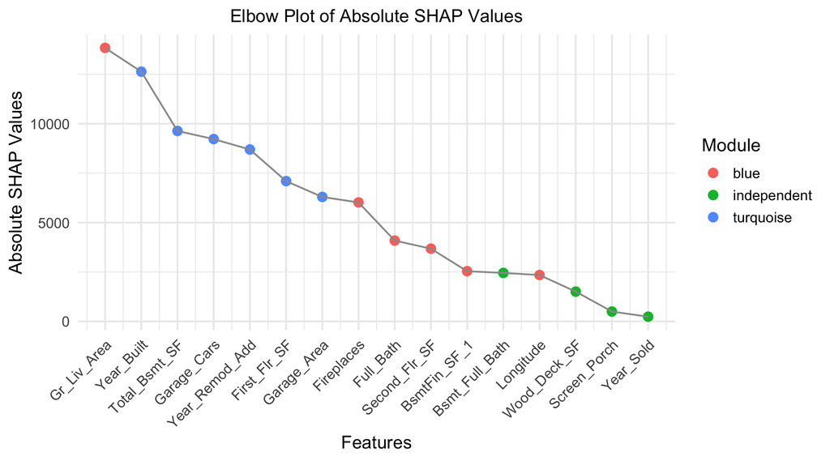

```r
plot_elbow(fits$within_mdml)
```